# Exercises 9.16 - 9.20 - Simple Normal Regression

Projekt

Dana Kozáková TBD

2026-07-12

## Úvod

Cvičenia 9.16 až 9.20 z knihy [Bayes Rules!](https://www.bayesrulesbook.com/chapter-9)

**Simple Normal Regression** - Bayesovská jednoduchá normálna regresia pre modelovanie vzťahu medzi kvantitatívnou responzovou premennou $Y$ a kvantitatívnym prediktorom $X$.

## Kľúčové vzorce z kapitoly 9

### 9.1 Building the regression model

#### 9.1.1 Data model - Štruktúra dátového modelu

**Simple Normal Regression Model:**

$$\begin{equation}
Y_i | \beta_0, \beta_1, \sigma \stackrel{ind}{\sim} N\left(\mu_i,
\sigma^2\right) \;\; \text{ with } \;\; \mu_i = \beta_0 + \beta_1X_i
\tag{9.3}
\end{equation}$$

kde:

- $Y_i$ je hodnota responzovej premennej pre $i$-té pozorovanie
- $X_i$ je hodnota prediktora pre $i$-té pozorovanie
- $\mu_i = \beta_0 + \beta_1X_i$ je stredná hodnota $Y$ pri danej hodnote $X_i$
- $\beta_0$ je **intercept** (priesečník) - typická hodnota $Y$ pri $X = 0$
- $\beta_1$ je **slope** (sklon) - typická zmena v $Y$ pri zvýšení $X$ o jednu jednotku
- $\sigma$ je **štandardná odchýlka** - miera variability $Y$ okolo strednej hodnoty $\mu_i$

**Interpretácia parametrov:**

- **Intercept coefficient** $\beta_0$: technicky označuje typickú hodnotu responzovej premennej, keď prediktor má hodnotu 0 ($X_i = 0$). Zabezpečuje základnú úroveň modelu pozdĺž y-osi.
- **Slope coefficient** $\beta_1$: označuje typickú zmenu v responzovej premennej pri zvýšení prediktora o jednu jednotku.
- **Standard deviation** $\sigma$: meria variabilitu pozorovaných hodnôt okolo lokálnej strednej hodnoty $\mu_i$. Menšie $\sigma$ znamená silnejší vzťah medzi $Y$ a $X$.

#### 9.1.2 Prior models - Apriórne modely

**Priors pre regresné parametre:**

$$\begin{equation}
\begin{split}
\beta_0 & \sim N\left(m_0, s_0^2 \right) \\
\beta_1 & \sim N\left(m_1, s_1^2 \right) \\
\end{split}
\tag{9.4}
\end{equation}$$

$$\begin{equation}
\sigma \sim \text{Exp}(l)
\tag{9.5}
\end{equation}$$

Pre Exponenciálne rozdelenie platí:
$$E(\sigma) = \frac{1}{l} \;\; \text{ a } \;\;
SD(\sigma) = \frac{1}{l}$$

#### 9.1.3 Complete Bayesian Model - Kompletný Bayesovský model

**Bayesian Simple Linear Regression Model:**

$$\begin{equation}
\begin{array}{lcrl}
\text{data:} & \hspace{.05in} & Y_i | \beta_0, \beta_1, \sigma
& \stackrel{ind}{\sim} N\left(\mu_i, \sigma^2\right) \;\; \text{
with } \;\; \mu_i = \beta_0 + \beta_1X_i \\
\text{priors:} & & \beta_0 & \sim N\left(m_0, s_0^2 \right)
\\
& & \beta_1 & \sim N\left(m_1, s_1^2 \right) \\
& & \sigma & \sim \text{Exp}(l) \\
\end{array}
\tag{9.6}
\end{equation}$$

### 9.2 Tuning priors - Ladenie apriórnych modelov

**Centered intercept** $\beta_{0c}$: Namiesto $\beta_0$ (intercept pri $X=0$) často používame centrovaný intercept $\beta_{0c}$, ktorý označuje typickú hodnotu $Y$ pri priemernej hodnote $X$.

### 9.3 Posterior simulation - Posteriorna simulácia

**MCMC simulácia pomocou `stan_glm()`:**

```r
model <- stan_glm(Y ~ X, data = dataset,
                  family = gaussian,
                  prior_intercept = normal(m0, s0),
                  prior = normal(m1, s1),
                  prior_aux = exponential(rate),
                  chains = 4, iter = 5000*2)
```

**Diagnostika MCMC:**

- `neff_ratio()` - pomer efektívnej veľkosti vzorky (mala by byť > 0.1)
- `rhat()` - R-hat hodnoty (mali by byť blízko 1.0)
- `mcmc_trace()` - trace plots pre vizuálnu kontrolu konvergencie
- `mcmc_dens_overlay()` - density plots pre porovnanie reťazcov

### 9.4 Posterior interpretation - Interpretácia posterioru

**Posteriorna sumarizácia:**

```r
tidy(model, effects = c("fixed", "aux"),
     conf.int = TRUE, conf.level = 0.80)
```

**Posteriorne pravdepodobné modelové čiary:**

Pre vizualizáciu posterioru sa používa funkcia `add_fitted_draws()` z balíka `tidybayes`:

```r
data %>%
  add_fitted_draws(model, n = 50) %>%
  ggplot(aes(x = X, y = Y)) +
  geom_line(aes(y = .value, group = .draw), alpha = 0.15) +
  geom_point(data = data, size = 0.5)
```

### 9.5 Posterior prediction - Posteriorna predikcia

**Dva typy intervalov:**

1. **Posterior credible interval pre $\mu$**: Interval pre priemernú hodnotu $Y$ pri danom $X$
2. **Posterior prediction interval pre $Y_{new}$**: Interval pre konkrétnu novú hodnotu $Y$ pri danom $X$

Prediction interval je širší, pretože zahŕňa: - Variabilitu v parametroch $(\beta_0, \beta_1, \sigma)$ - Variabilitu jednotlivých pozorovaní okolo strednej hodnoty

**Simulácia posteriorne prediktívneho modelu:**

```r
# Manuálna simulácia
model_df <- as.data.frame(model)
predictions <- model_df %>%
  mutate(mu = `(Intercept)` + predictor_name * x_value,
         y_new = rnorm(n(), mean = mu, sd = sigma))

# Pomocou funkcie posterior_predict()
predictions <- posterior_predict(model,
                                newdata = data.frame(predictor = x_value))
```

## Exercise 9.16: Penguins - Prior Model

> The `penguins_bayes` dataset in the bayesrules package includes data on 344 penguins. In the next exercises, you will use this data to model the length of penguin flippers in mm ($Y$) by the length of their bills in mm ($X$). We have a general sense that the average penguin has flippers that are somewhere between 150mm and 250mm long. Beyond that, we don’t have a strong understanding of the relationship between flipper and bill length, and thus will otherwise utilize weakly informative priors.
> 1. Simulate the Normal regression prior model of `flipper_length_mm` by `bill_length_mm` using 4 chains for 10000 iterations each. HINT: You can use the same `stan_glm()` syntax that you would use to simulate the posterior, but include `prior_PD = TRUE`.
> 2. Check the `prior_summary()` and use this to write out the complete structure of your Normal regression model (9.6).
> 3. Plot 100 prior plausible model lines ($\beta_0 + \beta_1 X$) and 4 datasets simulated under the priors.
> 4. Summarize your weakly informative prior understanding of the relationship between flipper and bill length.

### a. Apriórny model

**Dáta v apriórnom modeli**

```
##  flipper_length_mm bill_length_mm
##  Min.   :172.0     Min.   :32.10
##  1st Qu.:190.0     1st Qu.:39.23
##  Median :197.0     Median :44.45
##  Mean   :200.9     Mean   :43.92
##  3rd Qu.:213.0     3rd Qu.:48.50
##  Max.   :231.0     Max.   :59.60
##  NA's   :2         NA's   :2
```

```
## Pozorovani:  344
```

**Nastavenie prior modelu:**

- V zadaní je uvedené, že použijeme málo informatívne apriórne modely, keďže máme málo predpokladov o dátach. Preto nastavíme parameter `autoscale` v metóde pre parametre $\beta_1$ a $\sigma$ na `TRUE`. `Rstanarm` tak automaticky upraví smerodajnú odchýlku pre prior podľa dát.
- Taktiež nemáme predpoklad o smere závislosti, či je kladná alebo záporná. Preto nastavíme strednú hodnotu prioru pre koeficient $\beta_1$ na nulu.

**ZADANÉ HYPERPARAMETRE:**

- Intercept: $m_0 = 200$, $s_0 = 25$ (z intervalu 150-250mm)
- Slope: $m_1 = 0$, $s_1$ - weakly informative (autoscale)
- Sigma: $l$ - weakly informative (autoscale)

**APRIÓRNY MODEL:**

$$\begin{align}
\text{Data: } \quad Y_i | \beta_0, \beta_1, \sigma
&\stackrel{ind}{\sim} N(\mu_i, \sigma^2)
\quad\text{kde} \quad \mu_i = \beta_0 + \beta_1 X_i \\
\text{Priors: } \quad \beta_{0c} &\sim N(m_0 = 200, s_0^2 = 25^2)
\quad \text{informatívny} \\
\beta_1 &\sim N(m_1 = 0, s_1^2)
\quad \text{málo informatívny} \\
\sigma &\sim \text{Exp}(l)
\quad \text{málo informatívny}
\end{align}$$

```r
# Zadanie: flippers are somewhere between 150mm and 250mm
m0 <- 200 # (150 + 250) / 200
s0 <- 25 # (250 - m0) / 2
# we don’t have a strong understanding of the relationship between flipper and bill length

m1 <- 0
# s1 nechame na rstanarm odhadnut

penguin_prior <- stan_glm(
  flipper_length_mm ~ bill_length_mm,
  data = penguins_bayes,
  family = gaussian,
  prior_intercept = normal(m0, s0, autoscale = FALSE),
  prior = normal(0, 2.5, autoscale = TRUE),  # default hodnoty
  prior_aux = exponential(1, autoscale = TRUE),
  chains = 4,
  iter = 10000,
  prior_PD = TRUE,
  refresh = 0 # potlaci vypis MCMC na vystupe
)
```

### b. Štruktúra modelu

```
## Priors for model 'penguin_prior'
## ------
## Intercept (after predictors centered)
##  ~ normal(location = 200, scale = 25)
##
## Coefficients
##   Specified prior:
##     ~ normal(location = 0, scale = 2.5)
##   Adjusted prior:
##     ~ normal(location = 0, scale = 6.4)
##
## Auxiliary (sigma)
##   Specified prior:
##     ~ exponential(rate = 1)
##   Adjusted prior:
##     ~ exponential(rate = 0.071)
## ------
## See help('prior_summary.stanreg') for more details
```

Vidíme, že po apriórny model sa aktualizoval takto:

### c. Vizualizácia apriórnych modelov

**Graf: 100 apriórnych modelových čiar**

```
## Po odstránení NA: 342 pozorovaní
```

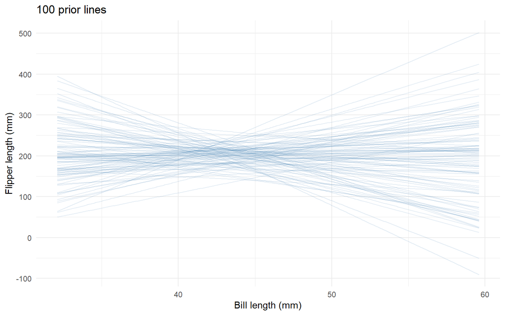

**Datasety - možné scénare:** - každý dataset predstavuje 342 simulovaných hodnôt **flipper_length** pre každého tučniaka vytvorených podľa našej predstavy pred skutočným videním dát - 4 trojice náhodných hodnôt pre hyperparametre z MCMC

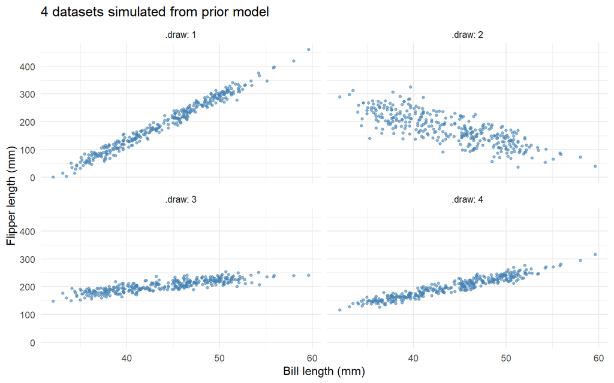

### d. Sumarizácia apriórneho pochopenia

Prior model odráža našu neistotu pred preskúmaním dát:

**Vieme:**

- Typický tučniak má plutvy cca 200mm (150-250mm)

**Nevieme:**

- Či existuje vzťah medzi zobákom a plutvami
- Ak áno, či je pozitívny alebo negatívny a ako silný

**Z prvého grafu 100 priamok:**

- 100 priamok rôznej šikmosti: aj rastúce, aj klesajúce
- vačšina čiar prechádza okolo 200 mm pri stredných hodnotách zobáka
- široký rozptyl –> veľká neistota

**Z grafu 2 - 4 simulované datasety**

## Exercise 9.17: Penguins - Data Exploration

> 1. Plot and discuss the observed relationship between `flipper_length_mm` and `bill_length_mm` among the 344 sampled penguins.
> 2. Does simple Normal regression seem to be a reasonable approach to modeling this relationship? Explain.

### a. Vizualizácia dát

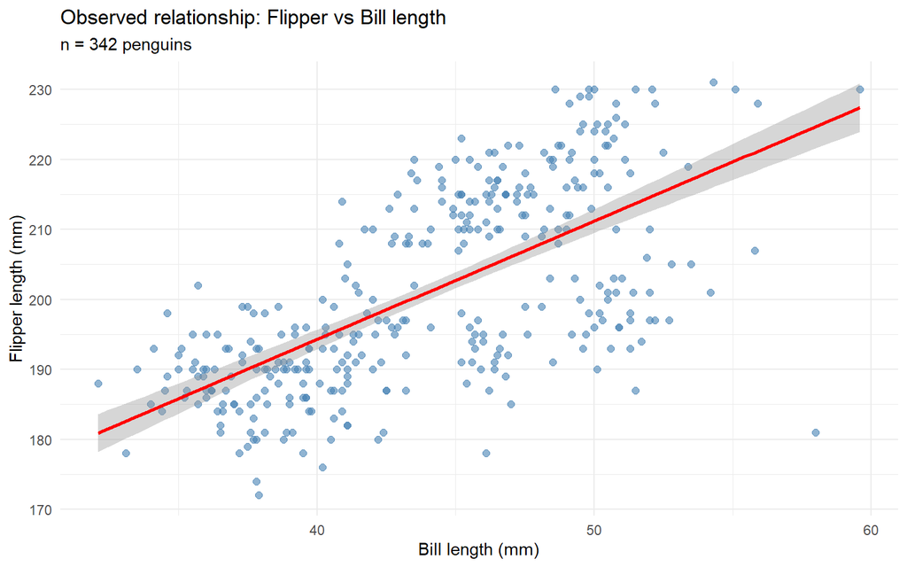

```r
penguins_clean %>%
  ggplot(aes(x = bill_length_mm, y = flipper_length_mm)) +
  geom_point(alpha = 0.6, color = "steelblue", size = 2) +
  geom_smooth(method = "lm", se = TRUE, color = "red", linewidth = 1) +
  labs(title = "Observed relationship: Flipper vs Bill length",
       subtitle = paste0("n = ", nrow(penguins_clean), " penguins"),
       x = "Bill length (mm)",
       y = "Flipper length (mm)"
       ) +
  theme_minimal()
```

```r
cor_bill <- cor(penguins_clean$bill_length_mm, penguins_clean$flipper_length_mm)
r_bill_squared <- cor_bill^2

n <- nrow(penguins_clean)
```

Medzi 342 tučniakmi vidíme pozitívny lineárny vzťah. Korelačný koeficient je **r = 0.656**. Teda `bill length` vysvetľuje približne **43.1%** variability v dĺžke plutvy.

### b. Vhodnosť normálnej regresie

**Kontrola predpokladov:**

1. **Linearita:** Vzťah vyzerá lineárne, nie je viditeľné nejaké zakrivenie.
2. **Normalita a homoskedasticita:** Rozptyl bodov okolo čiary vyzerá približne konštantný.
3. **Nezávislosť:** Každý tučniak predstavuje samostatné pozorovanie.

Simple Normal regression je vhodný.

## Exercise 9.18: Penguins - Posterior Analysis

> 1. Use `stan_glm()` to simulate the Normal regression posterior model. HINT: You can either do this from scratch or `update()` your prior simulation from Exercise 9.16 using `prior_PD = FALSE`.
> 2. Plot 100 posterior model lines for the relationship between flipper and bill length.
> 3. Provide a `tidy()` summary of your posterior model, including 90% credible intervals.
> 4. Interpret the 90% posterior credible interval for the `bill_length_mm` coefficient, $\beta_1$.
> 5. Do we have ample posterior evidence that penguins with longer bills tend to have longer flippers? Explain.

### a. Posteriorna simulácia

```r
penguin_posterior <- update(penguin_prior, prior_PD = FALSE)

coef_summary <- tidy(penguin_posterior, effects = c("fixed", "aux"))
print(coef_summary)
```

```
## # A tibble: 4 × 3
##   term           estimate std.error
##   <chr>             <dbl>     <dbl>
## 1 (Intercept)      127.       4.73
## 2 bill_length_mm     1.69     0.106
## 3 sigma             10.6      0.411
## 4 mean_PPD         201.       0.814
```

### b. Graf 100 posteriórnych priamok

Porovnanie priórnych a posteriórnych priamok

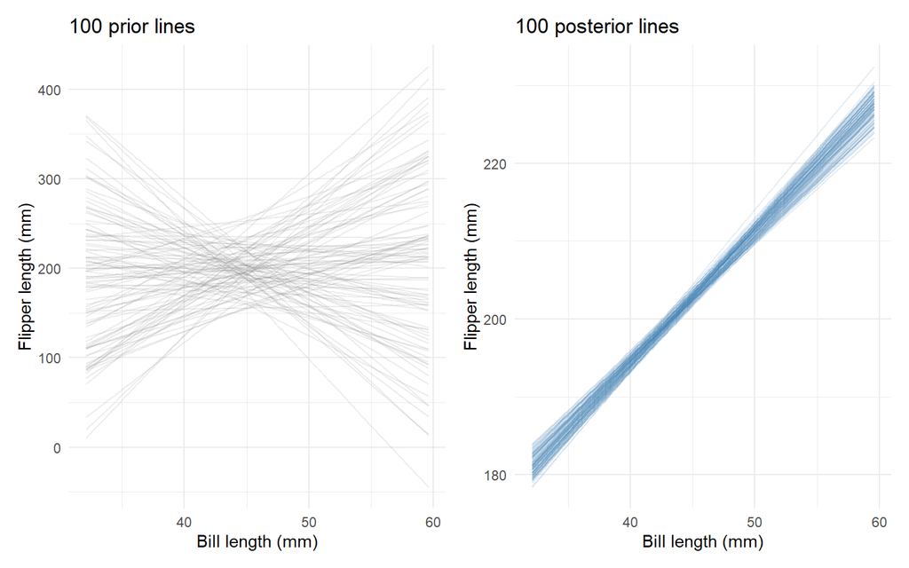

```r
plot_prior_lines <- penguins_clean %>%
  add_epred_draws(penguin_prior, ndraws = 100) %>%
  ggplot(aes(x = bill_length_mm, y = flipper_length_mm)) +
  geom_line(aes(y = .epred, group = .draw), alpha = 0.15, color = "grey50") +
  labs(title = "100 prior lines",
       x = "Bill length (mm)",
       y = "Flipper length (mm)") +
  theme_minimal()

plot_posterior_lines <- penguins_clean %>%
  add_epred_draws(penguin_posterior, ndraws = 100) %>%
  ggplot(aes(x = bill_length_mm, y = flipper_length_mm)) +
  geom_line(aes(y = .epred, group = .draw), alpha = 0.15, color = "steelblue") +
  labs(title = "100 posterior lines",
       x = "Bill length (mm)",
       y = "Flipper length (mm)") +
  theme_minimal()

plot_prior_lines + plot_posterior_lines
```

### c. Tidy summary s 90% CI

```r
posterior_summary <- tidy(penguin_posterior,
                          effects = c("fixed", "aux"),
                          conf.int = TRUE,
                          conf.level = 0.90)

posterior_summary$term <- c("β₀ (Intercept)",
                            "β₁ (bill_length_mm)",
                            "σ (sigma)",
                            "mean_PPD")

posterior_summary %>%
  select(term, estimate, conf.low, conf.high) %>%
  mutate(across(where(is.numeric), ~round(., 2))) %>%
  kable(col.names = c("Parameter", "Median", "90% CI Lower", "90% CI Upper"),
        caption = "Posterior summary with 90% credible intervals")
```

Posterior summary with 90% credible intervals

| Parameter | Median | 90% CI Lower | 90% CI Upper |
| --- | --- | --- | --- |
| β₀ (Intercept) | 126.75 | 119.09 | 134.41 |
| β₁ (bill_length_mm) | 1.69 | 1.52 | 1.86 |
| σ (sigma) | 10.64 | 10.00 | 11.35 |
| mean_PPD | 200.93 | 199.58 | 202.27 |

```r
b0 <- round(posterior_summary$estimate[1], 2)
b1 <- round(posterior_summary$estimate[2], 2)
b1_l <- round(posterior_summary$conf.low[2], 2)
b1_h <- round(posterior_summary$conf.high[2], 2)
sigma <- round(posterior_summary$estimate[3], 2)
```

### d. Interpretácia 90% posteriórneho kredibilného intervalu pre $\beta_1$

Za každý **1mm nárast v dĺžke zobáka**, dĺžka plutiev v priemere **narastie o 1.69 mm**.

- S 90% pravdepodobnosťou je skutočná hodnota $\beta_1$ medzi 1.52 a 1.86 mm. To znamená, že sme si na 90% istí, že za každý 1mm dlhší zobák sú plutvy dlhšie o približne 1.52 až 1.86 mm.

### e. Preukázanie posteriórneho vzťahu

- Celý interval je **nad nulou** -> čiže silná evidencia pre pozitívny vzťah
- To možno vidieť aj na grafoch 100 priamok, všetky majú pozitívny sklon -> žiadna posteriórna vzorka nenaznačuje negatívny vzťah

## Exercise 9.19: Penguins - Posterior Prediction

> Suppose we meet Pablo the penguin whose bill is 51mm long.
> 1. Without using the `posterior_predict()` shortcut function, simulate the posterior model for the typical flipper length among penguins with 51mm bills as well as the posterior predictive model for Pablo’s flipper length.
> 2. Construct, discuss, and compare density plot visualizations for the two separate posterior models in part a.
> 3. Calculate and interpret an 80% posterior prediction interval for Pablo’s flipper length.
> 4. Would the 80% credible interval for the typical flipper length among all penguins with 51mm bills be wider or narrower? Explain.
> 5. Use `posterior_predict()` to confirm your results to parts b and c.

### a. Manuálna simulácia predikcie

odhadnúř dĺžku plutvy, ak poznáme, že bill je 51 mm

```r
pablo_bill <- 51
# extrahovanie vzoriek z posterioru
posterior_df <- as.data.frame(penguin_posterior)
posterior_df |> head()
```

```
##   (Intercept) bill_length_mm    sigma
## 1    122.8867       1.761960 11.31554
## 2    126.1980       1.715615 10.95504
## 3    126.7226       1.702694 10.72993
## 4    118.0932       1.851813 11.10560
## 5    126.4341       1.678124 10.94257
## 6    130.3444       1.607041 10.05025
```

```r
# pre kazdy riadok vypocitat odhad strednej hodnoty dlzky plutvy = typicka dlzka posterior pre mu
# mu = beta_0 + beta_1 * 51
posterior_df <- posterior_df %>%
  mutate(mu = `(Intercept)` + bill_length_mm * pablo_bill)

# pre kazdy riadok simulovat odhad dlzky Pablovej plutvy = Y
# Y ~ N(mu, sigma)
posterior_df <- posterior_df %>%
  mutate(y = rnorm(n = n(), mean = mu, sd = sigma))

# Summary štatistiky
mu_median <- median(posterior_df$mu)
mu_lower <- quantile(posterior_df$mu, 0.10)
mu_upper <- quantile(posterior_df$mu, 0.90)

y_median <- median(posterior_df$y)
y_lower <- quantile(posterior_df$y, 0.10)
y_upper <- quantile(posterior_df$y, 0.90)
```

**Posteriórny model**:
$$\begin{equation}
Y_i | \beta_0, \beta_1, \sigma \stackrel{ind}{\sim} N\left(\mu_i,
\sigma^2\right) \;\; \text{ kde } \;\; \mu_i = \beta_0 + \beta_1X_i \\
\end{equation}$$

### b. Porovnanie posteriorných modelov

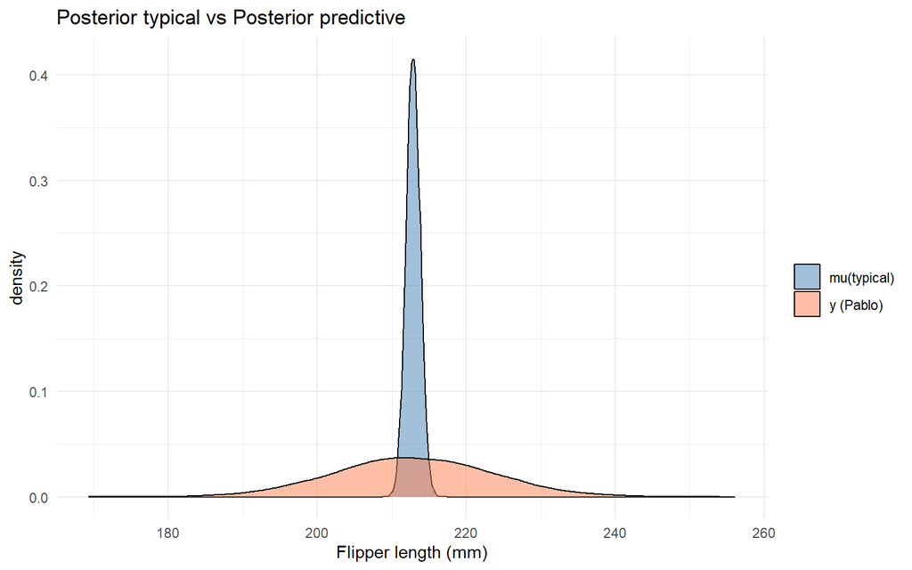

```r
posterior_df |> ggplot() +
  geom_density(aes(x = mu, fill = "mu(typical)"), alpha = 0.5) +
  geom_density(aes(x = y, fill = "y (Pablo)"), alpha = 0.5) +
  scale_fill_manual(values = c("steelblue", "coral")) +
  labs(title = "Posterior typical vs Posterior predictive",
       x = "Flipper length (mm)", fill = "") +
  theme_minimal()
```

### c. Prediction interval pre Pabla

```r
y_pi <- quantile(posterior_df$y, probs = c(0.10, 0.90))
```

**80% Posterior predikčný interval**: [199.2, 226.5] mm

S 80% pravdepodobnosťou má Pablo plutvy dlhé medzi 199.2 a 226.5 mm.

### d. Porovnanie šírok intervalov

Kredibilný interval pre typickú dĺžku plutvy je užší, lebo kredibilný interval zahŕňa len neistotu v hodnotách regresných parametrov. Predikčný interval zahŕňa aj individuálnu variabilitu od typickej hodnoty. Odhad priemeru je v užšom intervale ako odhad jedinca.

```r
mu_ci <- quantile(posterior_df$mu, probs = c(0.10, 0.90))
```

**80% kredibilný interval**: [211.7, 214.1] mm

Typická hodnota je v tomto intervale

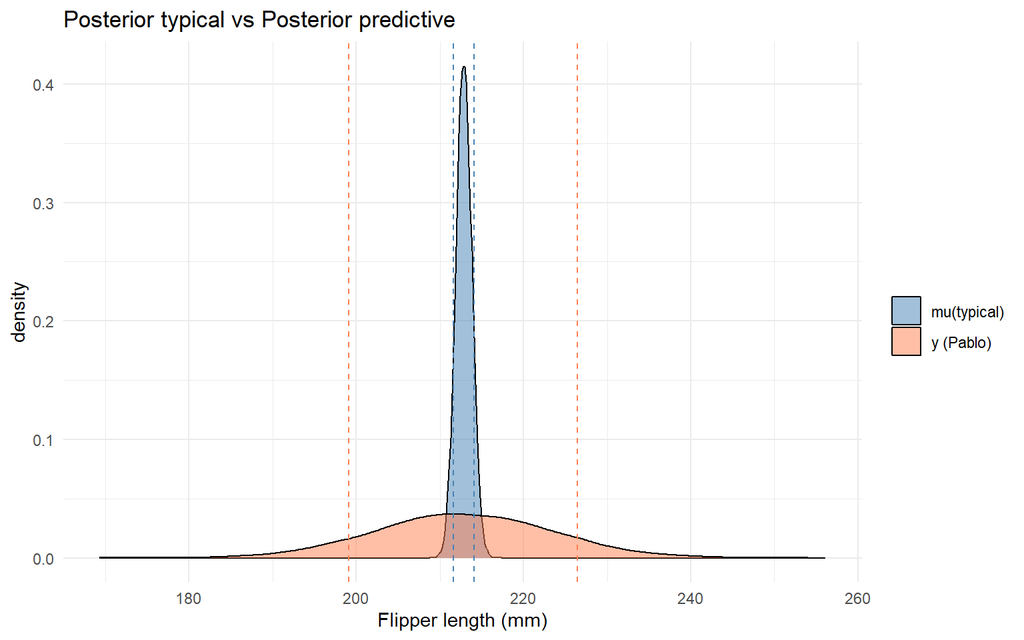

```r
posterior_df |> ggplot() +
  geom_density(aes(x = mu, fill = "mu(typical)"), alpha = 0.5) +
  geom_density(aes(x = y, fill = "y (Pablo)"), alpha = 0.5) +
  geom_vline(xintercept = mu_ci[1], color = "steelblue", linetype = "dashed") +
  geom_vline(xintercept = mu_ci[2], color = "steelblue", linetype = "dashed") +
  geom_vline(xintercept = y_pi[1], color = "coral", linetype = "dashed") +
  geom_vline(xintercept = y_pi[2], color = "coral", linetype = "dashed") +
  scale_fill_manual(values = c("steelblue", "coral")) +
  labs(title = "Posterior typical vs Posterior predictive",
       x = "Flipper length (mm)", fill = "") +
  theme_minimal()
```

### e. Overenie pomocou `posterior_predict()`

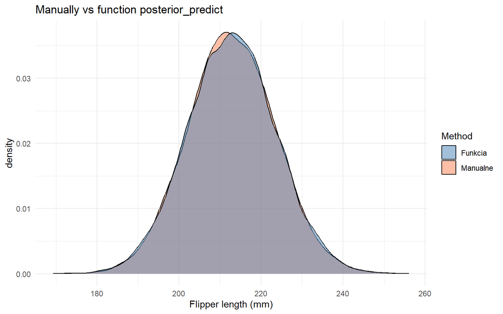

```r
post_pred <- posterior_predict(penguin_posterior,
                               newdata = data.frame(bill_length_mm = pablo_bill)) |>
  as.vector()

comparison_df <- data.frame(
  manual = posterior_df$y,
  fun = post_pred
)

comparison_df |> ggplot() +
  geom_density(aes(x = manual, fill = "Manualne"), alpha = 0.5) +
  geom_density(aes(x = fun, fill = "Funkcia"), alpha = 0.5) +
  scale_fill_manual(values = c("steelblue", "coral")) +
  labs(title = "Manually vs function posterior_predict",
       x = "Flipper length (mm)",
       fill ="Method") +
  theme_minimal()
```

## Exercise 9.20: Penguins - Body Mass Model

> Instead of bill length, consider the Normal regression model of penguin flipper lengths ($Y$) by body mass in grams ($X$).

> a.Based on their study of penguins in other regions, suppose that researchers are quite certain about the relationship between flipper length and body mass, prior to seeing any data: $\beta_1 \sim N(0.01, 0.002^2)$. Describe their prior understanding.
> 2. Plot and discuss the observed relationship between `flipper_length_mm` and `body_mass_g` among the 344 sampled penguins.
> 3. In a simple Normal regression model of flipper length $Y$ by one predictor $X$, do you think that the $\sigma$ parameter is bigger when $X$ = bill length or when $X$ = body mass? Explain your reasoning and provide some evidence from the information you already have.
> 4. Use `stan_glm()` to simulate the Normal regression posterior model of flipper length by body mass using the researchers’ prior for $\beta_1$ and weakly informative priors for $\beta_{0c}$ and $\sigma$. Do so with 4 chains run for 10000 iterations each.
> 5. Plot the posterior model of the $\beta_1$ `body_mass_g` coefficient. Use this to describe the researchers’ posterior understanding of the relationship between flippers and mass and how, if at all, this evolved from their prior understanding.

### a. Apriórne pochopenie vzťahu

Výskumníci prepodkladajú, že $\beta_1$ ≈ 0.01 mm/g. To znamená: * Za každý **1g** nárastu hmotnosti → plutvy dlhšie o **0.01 mm** * Za každých **100g** -> plutvy dlhšie o **1 mm** * Za každý **1kg** -> plutvy dlhšie o **10 mm**

95% prior interval: 0.01 ± 2 * 0.002 = [0.006, 0.014]

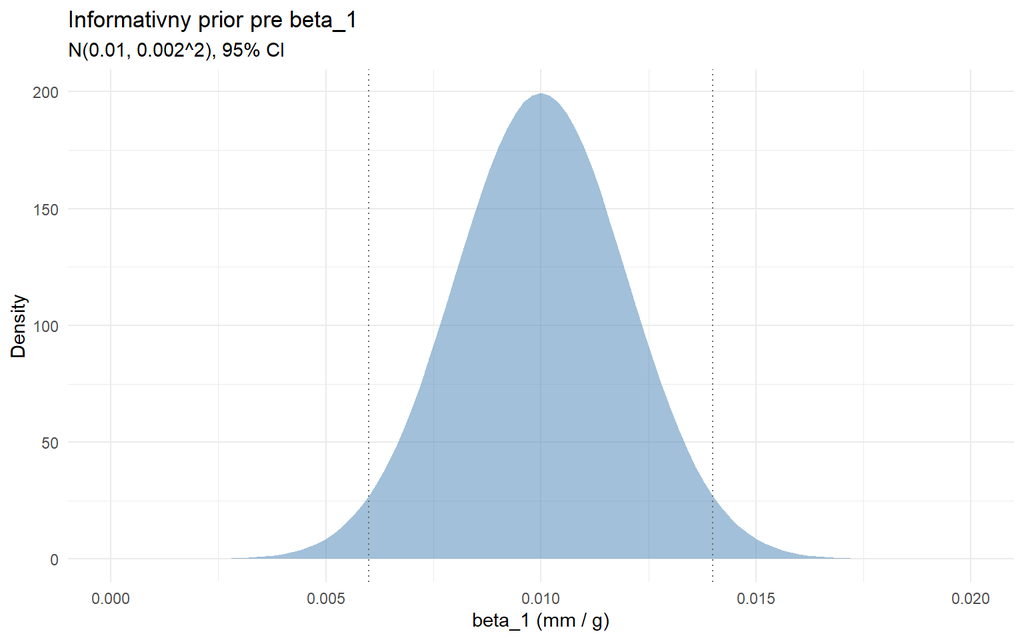

```r
# 95% interval
prior_lower <- 0.01 - 2*0.002
prior_upper <- 0.01 + 2*0.002

ggplot(data.frame(x = c(0, 0.02)), aes(x)) +
  stat_function(fun = dnorm, args = list(mean = 0.01, sd = 0.002),
                fill = "steelblue", geom = "area", alpha = 0.5) +
  geom_vline(xintercept = prior_lower, linetype = "dotted", color = "grey40") +
  geom_vline(xintercept = prior_upper, linetype = "dotted", color = "grey40") +
  labs(title = "Informativny prior pre beta_1",
       subtitle = "N(0.01, 0.002^2), 95% CI",
       x = "beta_1 (mm / g)",
       y = "Density") +
  theme_minimal()
```

### b. Vizualizácia vzťahu flipper length a body mass

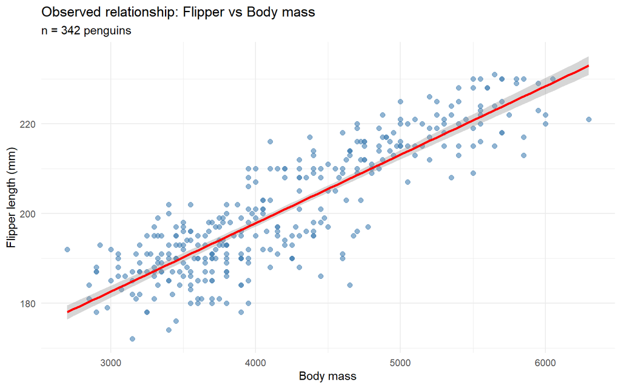

```r
penguins_clean %>%
  ggplot(aes(x = body_mass_g, y = flipper_length_mm)) +
  geom_point(alpha = 0.6, color = "steelblue", size = 2) +
  geom_smooth(method = "lm", se = TRUE, color = "red", linewidth = 1) +
  labs(title = "Observed relationship: Flipper vs Body mass",
       subtitle = paste0("n = ", nrow(penguins_clean), " penguins"),
       x = "Body mass",
       y = "Flipper length (mm)"
       ) +
  theme_minimal()
```

```r
cor_mass <- cor(penguins_clean$body_mass_g, penguins_clean$flipper_length_mm)
r_mass_squared <- cor_mass^2
```

Medzi 342 tučniakmi vidíme pozitívny lineárny vzťah. Korelačný koeficient je **r = 0.871**. Teda `body_mass_g` vysvetľuje približne **75.9%** variability dĺžky plutvy.

### c. Porovnanie $\sigma$ pre rôzne prediktory

$\sigma$ meria rozptyl okolo priamky: $Y_i \sim N(\beta_0 + \beta_1 X_i, \sigma^2)$ $\sigma$ je menšia pre body mass model.

Keď porovnáme dĺžku plutvy ako závislú premennú od jedného prediktora v jednoduchej normálnej regresii:

- `body mass` tesnejšie koreluje s dĺžkou plutvy ako `dĺžka zobáka`
- na grafe vidno, že body sú tu bližšie ku regresnej priamke
- teda rozptyl od typickej hodnoty je menší

Korelácie:

- Flipper vs Bill length: r = 0.656
- Flipper vs Body mass: r = 0.871
- `Body mass` má silnejšiu koreláciu (0.871 > 0.656)

#### d. Posteriorna simulácia s informatívnym priorom

- namiesto `weakly informative` prioru použijeme prior výskumníkov o $\beta_1$ koeficiente

```r
penguin_mass_posterior <- stan_glm(
  flipper_length_mm ~ body_mass_g,
  data = penguins_clean,
  family = gaussian,
  prior_intercept = normal(200, 2.5, autoscale = TRUE),
  prior = normal(0.01, 0.002, autoscale = FALSE),       # od vyskumnikov
  prior_aux = exponential(1, autoscale = TRUE),
  chains = 4,
  iter = 10000,
  refresh = 0
)

# Posterior summary
tidy(penguin_mass_posterior,
     effects = c("fixed", "aux"),
     conf.int = TRUE,
     conf.level = 0.90) %>%
  mutate(across(where(is.numeric), ~round(., 3)))
```

```
## # A tibble: 4 × 5
##   term        estimate std.error conf.low conf.high
##   <chr>          <dbl>     <dbl>    <dbl>     <dbl>
## 1 (Intercept)  138.        1.93   135.      141.
## 2 body_mass_g    0.015     0        0.014     0.016
## 3 sigma          6.93      0.269    6.51      7.39
## 4 mean_PPD     201.        0.529  200.      202.
```

#### e. Evolúcia pochopenia vzťahu

- porovnanie pochopenia regresného koeficientu na začiatku v priori a následne v posteriórnom modeli.

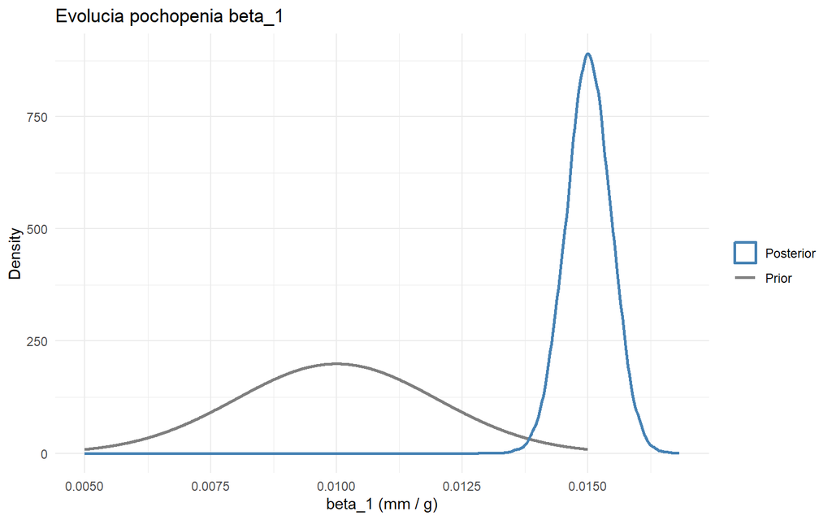

```r
# beta1 z posterior vzoriek
posterior_mass_df <- as.data.frame(penguin_mass_posterior)
beta1_posterior <- posterior_mass_df$body_mass_g # vektor 20,000 MCMC vzoriek beta_1

# data pre prior krivku
x_range <- seq(0.005, 0.015, length.out = 1000)
beta1_prior <- dnorm(x_range, mean = 0.01, sd = 0.002)

ggplot() +
  geom_line(aes(x = x_range, y = beta1_prior, color = "Prior"),
            linewidth = 1) +
  geom_density(data = data.frame(x = beta1_posterior),
               aes(x = x, color = "Posterior"),
               linewidth = 1) +
  scale_color_manual(values = c("Prior" = "grey50",
                                 "Posterior" = "steelblue")) +
  labs(title = "Evolucia pochopenia beta_1",
       x = "beta_1 (mm / g)",
       y = "Density",
       color = "") +
  theme_minimal()
```

Evolúcia pochopenia:

Prior: $\beta_1$ = 0.01 (výskumníci očakávali) Posterior: $\beta_1$ ≈ 0.015

Posterior je vyšší ako prior.